# Working with Distributions

## Distributions

Distributions are a set of classes available in `{reservr}` to specify distribution families of random variables. A Distribution inherits from the R6 Class `Distribution` and provides all functionality necessary for working with a specific family.

A Distribution can be defined by calling one of the constructor functions, prefixed by `dist_` in the package. All constructors accept parameters of the family as arguments. If these arguments are specified, the corresponding parameter is considered *fixed* in the sense that it need not be specified when computing something for the distribution and it will be assumed fixed when calling `fit()` on the distribution instance.

### Sample

For example, an unspecified normal distribution can be created by calling `dist_normal()` without arguments. This means the parameters `mean` and `sd` are considered *placeholders*. If we want to, e.g., sample from `norm`, we must specify these placeholders in the `with_params` argument:

```r
library(reservr)
set.seed(1L)
# Instantiate an unspecified normal distribution
norm <- dist_normal()
x <- norm$sample(n = 10L, with_params = list(mean = 3, sd = 1))

set.seed(1L)
norm2 <- dist_normal(sd = 1)
x2 <- norm2$sample(n = 10L, with_params = list(mean = 3))

# the same RVs are drawn because the distribution parameters and the seed were the same
stopifnot(identical(x, x2))
```

### Density

The `density()` function computes the density of the distribution with respect to its natural measure. Use `is_discrete_at()` to check if a point has discrete mass or lebesgue density.

```r
norm$density(x, with_params = list(mean = 3, sd = 1))
```

```
#>  [1] 0.3278626 0.3922715 0.2813724 0.1117603 0.3778620 0.2849269 0.3542572
#>  [8] 0.3037652 0.3380030 0.3807663
```

```r
dnorm(x, mean = 3, sd = 1)
```

```
#>  [1] 0.3278626 0.3922715 0.2813724 0.1117603 0.3778620 0.2849269 0.3542572
#>  [8] 0.3037652 0.3380030 0.3807663
```

```r
norm$density(x, log = TRUE, with_params = list(mean = 3, sd = 1)) # log-density
```

```
#>  [1] -1.1151607 -0.9358010 -1.2680761 -2.1913990 -0.9732262 -1.2555227
#>  [7] -1.0377321 -1.1915002 -1.0847006 -0.9655696
```

```r
norm$is_discrete_at(x, with_params = list(mean = 3, sd = 1))
```

```
#>  [1] FALSE FALSE FALSE FALSE FALSE FALSE FALSE FALSE FALSE FALSE
```

```r
# A discrete distribution with mass only at point = x[1].
dd <- dist_dirac(point = x[1])
dd$density(x)
```

```
#>  [1] 1 0 0 0 0 0 0 0 0 0
```

```r
dd$is_discrete_at(x)
```

```
#>  [1]  TRUE FALSE FALSE FALSE FALSE FALSE FALSE FALSE FALSE FALSE
```

`diff_density()` computes the gradient of the density with respect to each free parameter. Setting `log = TRUE` computes the gradient of the log-density, i.e., the gradient of `log f(x, params)` instead.

```r
norm$diff_density(x, with_params = list(mean = 3, sd = 1))
```

```
#> $mean
#>  [1] -0.20539076  0.07203805 -0.23512285  0.17828905  0.12450847 -0.23377349
#>  [7]  0.17267525  0.22427736  0.19461580 -0.11628160
#>
#> $sd
#>  [1] -0.19919475 -0.37904224 -0.08489705  0.17266080 -0.33683550 -0.09312311
#>  [7] -0.27009027 -0.13817569 -0.22594681 -0.34525522
```

### Probability

With `probability()`, the c.d.f., survival function, and their logarithms can be computed. For discrete distributions, `dist$probability(x, lower.tail = TRUE)` returns $P(X \le x)$ and `dist$probability(x, lower.tail = FALSE)` returns $P(X > x)$.

```r
norm$probability(x, with_params = list(mean = 3, sd = 1))
```

```
#>  [1] 0.2655087 0.5728534 0.2016819 0.9446753 0.6291140 0.2059746 0.6870228
#>  [8] 0.7698414 0.7176185 0.3800352
```

```r
pnorm(x, mean = 3, sd = 1)
```

```
#>  [1] 0.2655087 0.5728534 0.2016819 0.9446753 0.6291140 0.2059746 0.6870228
#>  [8] 0.7698414 0.7176185 0.3800352
```

```r
dd$probability(x)
```

```
#>  [1] 1 1 0 1 1 0 1 1 1 1
```

```r
dd$probability(x, lower.tail = FALSE, log.p = TRUE)
```

```
#>  [1] -Inf -Inf    0 -Inf -Inf    0 -Inf -Inf -Inf -Inf
```

Gradients of the (log-)c.d.f. or survival function with respect to parameters can be computed using `diff_probability()`.

```r
norm$diff_probability(x, with_params = list(mean = 3, sd = 1))
```

```
#> $mean
#>  [1] -0.3278626 -0.3922715 -0.2813724 -0.1117603 -0.3778620 -0.2849269
#>  [7] -0.3542572 -0.3037652 -0.3380030 -0.3807663
#>
#> $sd
#>  [1]  0.20539076 -0.07203805  0.23512285 -0.17828905 -0.12450847  0.23377349
#>  [7] -0.17267525 -0.22427736 -0.19461580  0.11628160
```

### Hazard

The hazard rate is defined by $h(x, \theta) = f(x, \theta) / S(x, \theta)$, i.e., the ratio of the density to the survival function.

```r
norm$hazard(x, with_params = list(mean = 3, sd = 1))
```

```
#>  [1] 0.4463805 0.9183533 0.3524565 2.0200785 1.0188091 0.3588385 1.1318948
#>  [8] 1.3198083 1.1969728 0.6141740
```

```r
norm$hazard(x, log = TRUE, with_params = list(mean = 3, sd = 1))
```

```
#>  [1] -0.80658365 -0.08517306 -1.04282794  0.70313635  0.01863443 -1.02488292
#>  [7]  0.12389301  0.27748652  0.17979571 -0.48747702
```

### Fitting

The `fit()` generic is defined for Distributions and will perform maximum likelihood estimation. It accepts a weighted, censored and truncated sample of class `trunc_obs`, but can automatically convert uncensored, untruncated observations without weight into the proper `trunc_obs` object.

```r
# Fit with mean, sd free
fit1 <- fit(norm, x)
# Fit with mean free
fit2 <- fit(norm2, x)
# Fit with sd free
fit3 <- fit(dist_normal(mean = 3), x)

# Fitted parameters
fit1$params
```

```
#> $mean
#> [1] 3.132203
#>
#> $sd
#> [1] 0.7405289
```

```r
fit2$params
```

```
#> $mean
#> [1] 3.132203
```

```r
fit3$params
```

```
#> $sd
#> [1] 0.752237
```

```r
# log-Likelihoods can be computed on
AIC(fit1$logLik)
```

```
#> [1] 26.37096
```

```r
AIC(fit2$logLik)
```

```
#> [1] 25.8626
```

```r
AIC(fit3$logLik)
```

```
#> [1] 24.68469
```

```r
# Convergence checks
fit1$opt$message
```

```
#> [1] "NLOPT_SUCCESS: Generic success return value."
```

```r
fit2$opt$message
```

```
#> [1] "NLOPT_SUCCESS: Generic success return value."
```

```r
fit3$opt$message
```

```
#> [1] "NLOPT_SUCCESS: Generic success return value."
```

### Fitting censored data

You can also fit interval-censored data.

```r
params <- list(mean = 30, sd = 10)
x <- norm$sample(100L, with_params = params)
xl <- floor(x)
xr <- ceiling(x)

cens_fit <- fit(norm, trunc_obs(xmin = xl, xmax = xr))
print(cens_fit)
```

```
#> $params
#> $params$mean
#> [1] 31.25
#>
#> $params$sd
#> [1] 9.112857
#>
#>
#> $opt
#> $opt$par
#>      mean        sd
#> 31.250000  9.112857
#>
#> $opt$value
#> [1] 362.9126
#>
#> $opt$iter
#> [1] 5
#>
#> $opt$convergence
#> [1] 1
#>
#> $opt$message
#> [1] "NLOPT_SUCCESS: Generic success return value."
#>
#>
#> $logLik
#> 'log Lik.' -362.9126 (df=2)
```

### Fitting truncated data

It is possible to fit randomly truncated samples, i.e., samples where the truncation bound itself is also random and differs for each observed observation.

```r
params <- list(mean = 30, sd = 10)
x <- norm$sample(100L, with_params = params)
tl <- runif(length(x), min = 0, max = 20)
tr <- runif(length(x), min = 0, max = 60) + tl

# truncate_obs() also truncates observations.
# if data is already truncated, use trunc_obs(x = ..., tmin = ..., tmax = ...) instead.
trunc_fit <- fit(norm, truncate_obs(x, tl, tr))
print(trunc_fit)
```

```
#> $params
#> $params$mean
#> [1] 26.72871
#>
#> $params$sd
#> [1] 8.242123
#>
#>
#> $opt
#> $opt$par
#>      mean        sd
#> 26.728710  8.242123
#>
#> $opt$value
#> [1] 203.8095
#>
#> $opt$iter
#> [1] 9
#>
#> $opt$convergence
#> [1] 1
#>
#> $opt$message
#> [1] "NLOPT_SUCCESS: Generic success return value."
#>
#>
#> $logLik
#> 'log Lik.' -203.8095 (df=2)
```

```r
attr(trunc_fit$logLik, "nobs")
```

```
#> [1] 62
```

### Plotting

Visualising different distributions, or parametrizations, e.g., fits, can be done with `plot_distributions()`

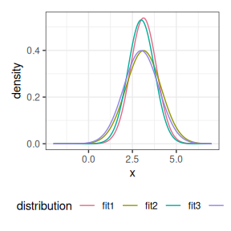

```r
# Plot fitted densities
plot_distributions(
  true = norm,
  fit1 = norm,
  fit2 = norm2,
  fit3 = dist_normal(3),
  .x = seq(-2, 7, 0.01),
  with_params = list(
    true = list(mean = 3, sd = 1),
    fit1 = fit1$params,
    fit2 = fit2$params,
    fit3 = fit3$params
  ),
  plots = "density"
)
```

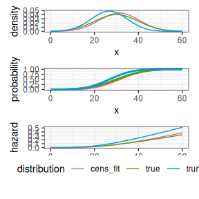

```r
# Plot fitted densities, c.d.f.s and hazard rates
plot_distributions(
  true = norm,
  cens_fit = norm,
  trunc_fit = norm,
  .x = seq(0, 60, length.out = 101L),
  with_params = list(
    true = list(mean = 30, sd = 10),
    cens_fit = cens_fit$params,
    trunc_fit = trunc_fit$params
  )
)
```

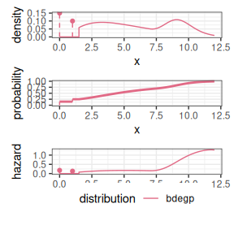

```r
# More complex distributions
plot_distributions(
  bdegp = dist_bdegp(2, 3, 10, 3),
  .x = c(seq(0, 12, length.out = 121), 1.5 - 1e-6),
  with_params = list(
    bdegp = list(
      dists = list(
        list(), list(), list(
          dists = list(
            list(
              dist = list(
                shapes = as.list(1:3),
                scale = 2.0,
                probs = list(0.2, 0.5, 0.3)
              )
            ),
            list(
              sigmau = 0.4,
              xi = 0.2
            )
          ),
          probs = list(0.7, 0.3)
        )
      ),
      probs = list(0.15, 0.1, 0.75)
    )
  )
)
```